# BildAktVR data analysis 2

Ondrej Havlicek

ohavlicek@gmail.com 06/2018 - 11/2018

## Preparations

### Verify the subject IDs and numbers of trials (incl.practice) we have

| subject | n |
| --- | --- |
| 7 | 168 |
| 8 | 168 |
| 9 | 168 |
| 10 | 168 |
| 11 | 168 |
| 12 | 168 |
| 13 | 168 |
| 14 | 168 |
| 15 | 168 |
| 16 | 168 |

[output cut: 34 more lines]

### Intervals estimation error distributions

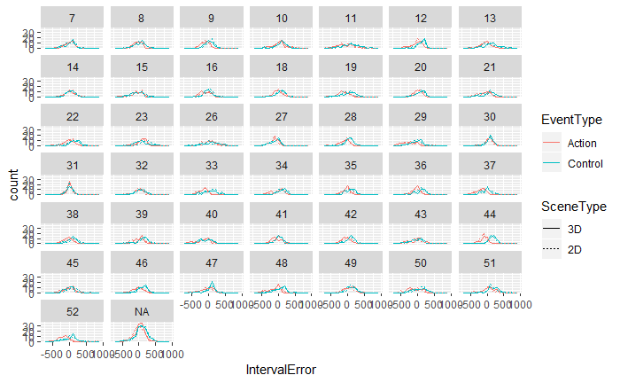

Interval estimation errors (Estimated - Actual) are pretty much normally distributed with pretty much similar variance across subjects and conditions

## Main results

### Main figure

Means of individual estimation errors as a distribution (violin plot with median of means) and a point estimate (mean of means) plus 95% CI for the mean

```
Ignoring unknown aesthetics: y
```

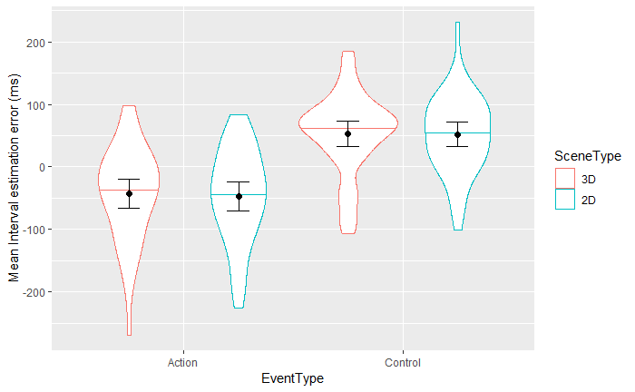

Intervals are judged more accurately in Action (Press-Beep) action, where they are slightly underestimated, than in Control (Vibration-Beep) condition, where they are overestimated. No obvious influence of 2D/3D scene type. Similar for mean and for median.

### Interval estimation error per interval length

Error bars are 95% CI for the mean

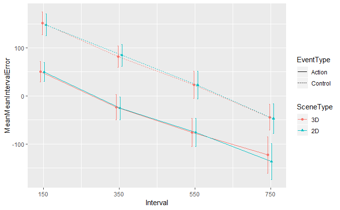

No influence of Scene type :-(

### Intervals: mixed-effects models - main output of analysis

- Model 1: Basic: IntervalError ~ IntervalS + SceneType * EventType + (1+IntervalS + SceneType + EventType|Subject)
- Model 2: Extd.: IntervalError ~ IntervalS + SceneType * EventType + abs(ObjectsError) + ObjectsCount * ObjectsRT + IntervalLogRT + (1+IntervalS+SceneType + EventType|Subject)

|  | Interval Error |  |  | Interval Error |  |  |
| --- | --- | --- | --- | --- | --- | --- |
| Predictors | Estimates | CI | p | Estimates | CI | p |
| (Intercept) | -44.49 | -67.05 – -21.92 | **<0.001** | 170.37 | 83.63 – 257.10 | **<0.001** |
| Interval S | -70.42 | -81.92 – -58.92 | **<0.001** | -71.41 | -82.80 – -60.01 | **<0.001** |
| SceneType2D | -3.92 | -16.17 – 8.32 | 0.530 | -4.06 | -16.26 – 8.14 | 0.515 |
| EventTypeControl | 96.74 | 76.40 – 117.08 | **<0.001** | 97.41 | 73.41 – 121.42 | **<0.001** |
| SceneType2D:EventTypeControl | 2.97 | -9.98 – 15.92 | 0.653 | 2.27 | -10.60 – 15.14 | 0.730 |
| abs(Objects Error) |  |  |  | 4.98 | -2.34 – 12.30 | 0.182 |
| Objects Count |  |  |  | 1.18 | -1.86 – 4.21 | 0.448 |
| Objects RT |  |  |  | -0.00 | -0.01 – 0.00 | 0.304 |
| Interval Log RT |  |  |  | -28.55 | -37.76 – -19.35 | **<0.001** |
| Trial Total |  |  |  | 0.24 | 0.10 – 0.37 | **0.001** |
| ObjectsCount:ObjectsRT |  |  |  | 0.00 | -0.00 – 0.00 | 0.791 |
| Random Effects |  |  |  |  |  |  |
| σ<sup>2</sup> | 18764.69 |  |  | 18532.80 |  |  |
| τ<sub>00</sub> | 5232.09 <sub>Subject</sub> |  |  | 6799.98 <sub>Subject</sub> |  |  |
| τ<sub>11</sub> | 1363.35 <sub>Subject.IntervalS</sub> |  |  | 1336.50 <sub>Subject.IntervalS</sub> |  |  |
|  | 740.35 <sub>Subject.SceneType2D</sub> |  |  | 739.77 <sub>Subject.SceneType2D</sub> |  |  |
|  | 3692.13 <sub>Subject.EventTypeControl</sub> |  |  | 5512.86 <sub>Subject.EventTypeControl</sub> |  |  |
| ρ<sub>01</sub> | 0.35 <sub>Subject.IntervalS</sub> |  |  | 0.29 <sub>Subject.IntervalS</sub> |  |  |
|  | -0.19 <sub>Subject.SceneType2D</sub> |  |  | -0.28 <sub>Subject.SceneType2D</sub> |  |  |
|  | -0.58 <sub>Subject.EventTypeControl</sub> |  |  | -0.69 <sub>Subject.EventTypeControl</sub> |  |  |
| ICC | 0.22 <sub>Subject</sub> |  |  | 0.27 <sub>Subject</sub> |  |  |
| Observations | 6880 |  |  | 6880 |  |  |
| Marginal R<sup>2</sup> / Conditional R<sup>2</sup> | 0.231 / 0.412 |  |  | 0.241 / 0.435 |  |  |

- Beta coefficients are in ms
- Intervals are more underestimated for longer (actual) intervals.
- :-( There is no effect of scene type, but we hypothesised that intervals will be underestimated more in 3D than in 2D..
- :-) The intervals are overestimated more in the Control than in Action condition - consistent with agency hypothesis, but it may be driven by factually different intervals in action than in control due to the VR SW and HW.. So we should probably rather look for an interaction:
- There is no interaction between Scene type (2D/3D) and Event type (Action/Control), but we wanted to find a bigger underestimation in 3D than 2D, in the Action than in the Control condition, right?
- Model which includes also error in objects estimation (measure of difficulty of the counting task, in absolute numbers) shows no interesting difference.

## Exploratory analyses and checks

### Effects found in the model

There was an effect of time (TrialTotal), but it seems to be small..

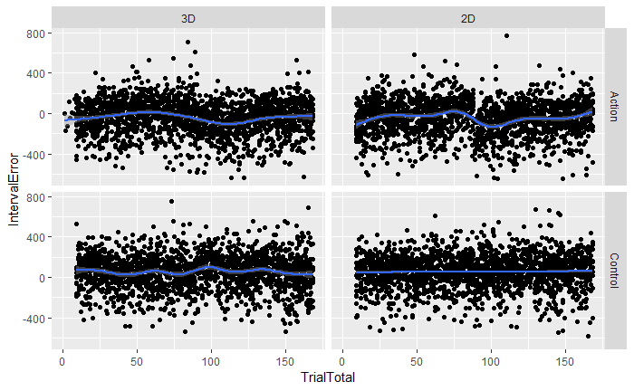

There was an effect of interval RT on interval error, but again seems to be not very interesting..

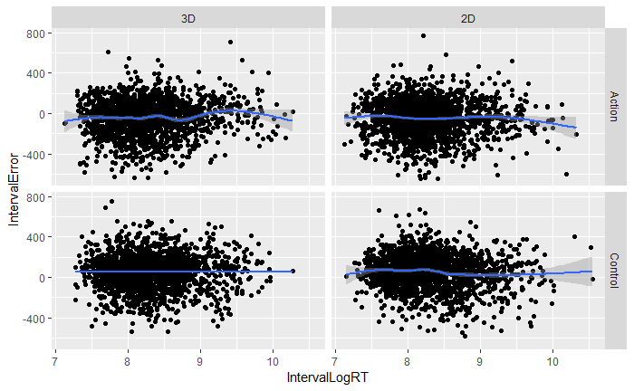

### Exclude trials which had inaccurate object estimation and too fast object responses

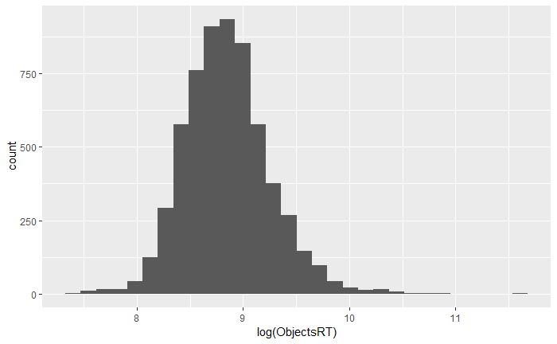

### Main results after excluding object counting errors and outlier RTs

```
the standard deviation is zerothe standard deviation is zerothe standard deviation is zerothe standard deviation is zerothe standard deviation is zerothe standard deviation is zeroIgnoring unknown aesthetics: y
```

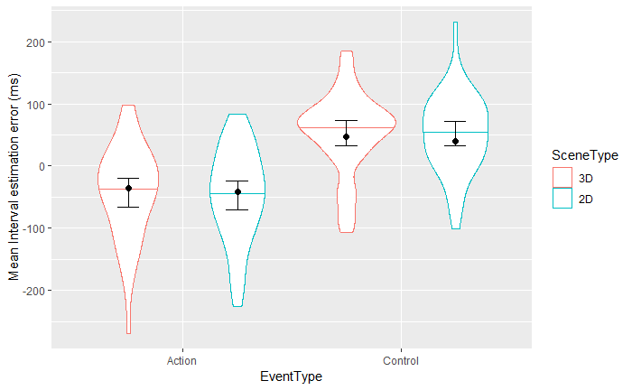

### The same per object count (more objects = more exploration = more effect?)

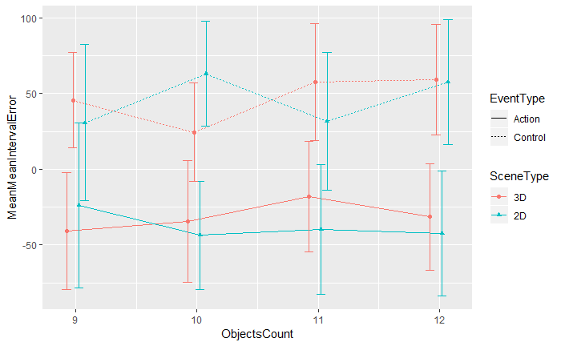

### Inferential test for outliers removed

```
Caution! ICC for random-slope-intercept models usually not meaningful. See 'Note' in `?icc`.
```

|  | Interval Error |  |  |
| --- | --- | --- | --- |
| Predictors | Estimates | CI | p |
| (Intercept) | -41.96 | -65.40 – -18.53 | **0.001** |
| Interval S | -65.74 | -72.71 – -58.77 | **<0.001** |
| SceneType2D | -1.43 | -20.59 – 17.72 | 0.883 |
| EventTypeControl | 89.27 | 60.20 – 118.33 | **<0.001** |
| SceneType2D:EventTypeControl | 0.62 | -26.20 – 27.44 | 0.964 |
| Random Effects |  |  |  |
| σ<sup>2</sup> | 18899.93 |  |  |
| τ<sub>00</sub> <sub>Subject</sub> | 3947.33 |  |  |
| τ<sub>11</sub> <sub>Subject.SceneType2D</sub> | 82.31 |  |  |
| τ<sub>11</sub> <sub>Subject.EventTypeControl</sub> | 5265.90 |  |  |
| ρ<sub>01</sub> <sub>Subject.SceneType2D</sub> | 1.00 |  |  |
| ρ<sub>01</sub> <sub>Subject.EventTypeControl</sub> | -0.63 |  |  |
| ICC <sub>Subject</sub> | 0.17 |  |  |
| Observations | 1655 |  |  |
| Marginal R<sup>2</sup> / Conditional R<sup>2</sup> | 0.212 / 0.353 |  |  |

### Explore a bit scenes distribution and randomization

Is the number of objects in a scene unrelated to the event-sound interval?

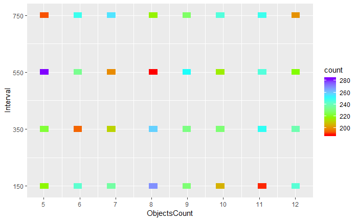

Number of objects inside a scene is not uniform across time interval: some combinations appear often, some less often. But the VR code seems properly randomized..

Let’s visualize it a bit more

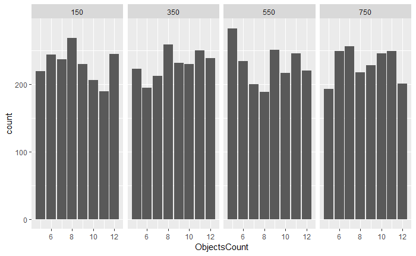

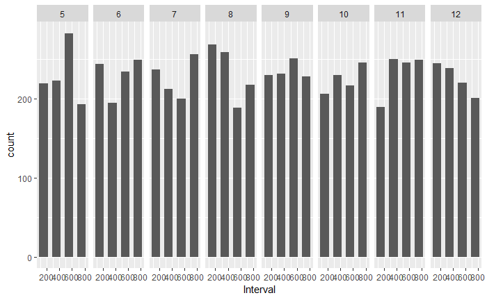

```
    Pearson's product-moment correlation

data:  ObjectsCount and Interval
t = 0.098036, df = 7358, p-value = 0.9219
alternative hypothesis: true correlation is not equal to 0
95 percent confidence interval:
 -0.0217043  0.0239889
sample estimates:
        cor
0.001142895
```

At least there is no linear relationship?

```
Call:
lm(formula = ObjectsCount ~ Interval + I(Interval^2) + I(Interval^3),
    data = data)

Residuals:
    Min      1Q  Median      3Q     Max
-3.6125 -1.8162 -0.0198  1.7765  3.5728

Coefficients:
                Estimate Std. Error t value Pr(>|t|)
(Intercept)    7.700e+00  2.939e-01  26.202  < 2e-16 ***
Interval       7.364e-03  2.679e-03   2.749  0.00600 **
I(Interval^2) -1.815e-05  6.735e-06  -2.696  0.00704 **
I(Interval^3)  1.303e-08  4.964e-09   2.625  0.00868 **
---
Signif. codes:  0 ‘***’ 0.001 ‘**’ 0.01 ‘*’ 0.05 ‘.’ 0.1 ‘ ’ 1

Residual standard error: 2.286 on 7356 degrees of freedom
Multiple R-squared:  0.001033,  Adjusted R-squared:  0.000626
F-statistic: 2.536 on 3 and 7356 DF,  p-value: 0.0549
```

Interestingly we have now linear, quadratic and cubic trend, but overal R2 is pretty much zero, so there is no practically significant relation between interval and number of objects.

### Objects error exploration

Distributions of object estimation errors (error = estimated - actual) for each participant:

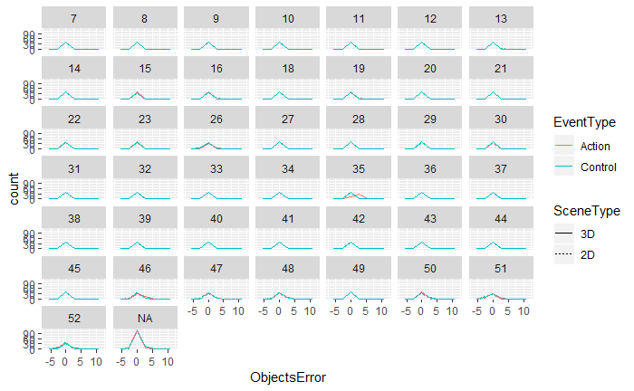

People are mostly correct about the object count.

What about relation of error on the number of actual objects?

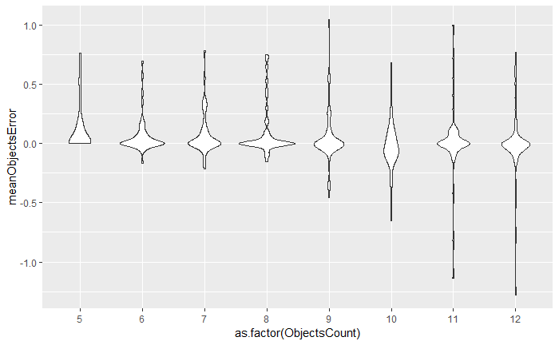

More objects do not mean on average larger error, but more variance..

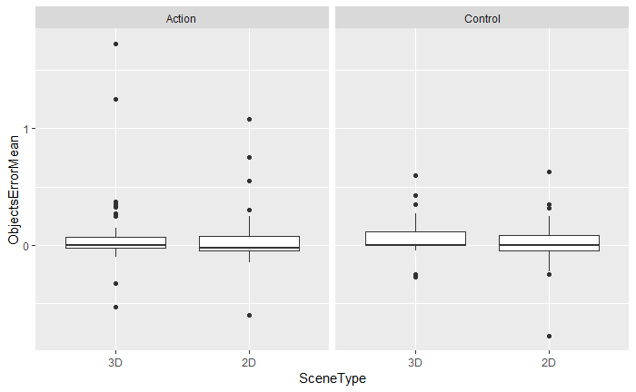

There seems to be no difference in object count estimation among conditions, which is good.

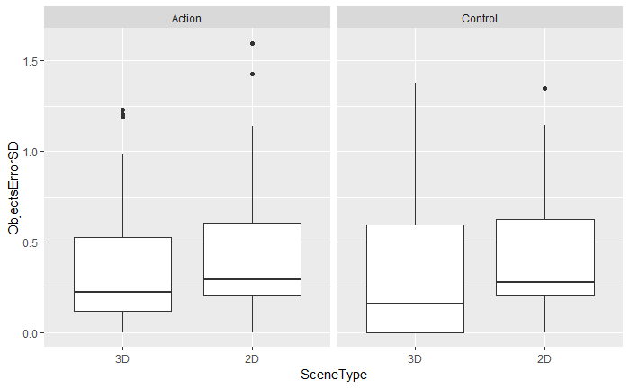

Precision seems to be slightly better for 3D than for 2D scenes

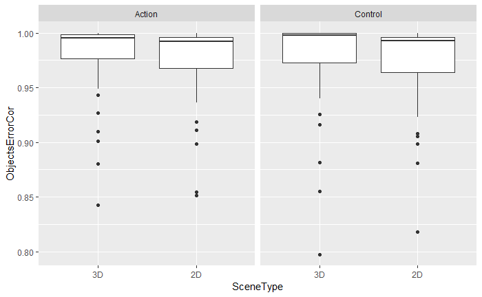

Not much of a difference in correlation between actual and estimated number of objects, only very tiny benefit of 3D.

### Objects: mixed-effects model

ObjectsError ~ ObjectsCount + SceneType*EventType + (1+ObjectsCount + SceneType + EventType|Subject)

|  | Objects Error |  |  |
| --- | --- | --- | --- |
| Predictors | Estimates | CI | p |
| (Intercept) | 0.25 | 0.12 – 0.39 | **0.001** |
| Objects Count | -0.02 | -0.03 – -0.00 | **0.017** |
| SceneType2D | -0.05 | -0.10 – -0.00 | 0.053 |
| EventTypeControl | -0.04 | -0.11 – 0.04 | 0.320 |
| SceneType2D:EventTypeControl | 0.00 | -0.05 – 0.05 | 0.919 |
| Random Effects |  |  |  |
| σ<sup>2</sup> | 0.26 |  |  |
| τ<sub>00</sub> <sub>Subject</sub> | 0.18 |  |  |
| τ<sub>11</sub> <sub>Subject.ObjectsCount</sub> | 0.00 |  |  |
| τ<sub>11</sub> <sub>Subject.SceneType2D</sub> | 0.01 |  |  |
| τ<sub>11</sub> <sub>Subject.EventTypeControl</sub> | 0.05 |  |  |
| ρ<sub>01</sub> <sub>Subject.ObjectsCount</sub> | -0.73 |  |  |
| ρ<sub>01</sub> <sub>Subject.SceneType2D</sub> | -0.72 |  |  |
| ρ<sub>01</sub> <sub>Subject.EventTypeControl</sub> | -0.54 |  |  |
| ICC <sub>Subject</sub> | 0.40 |  |  |
| Observations | 6880 |  |  |
| Marginal R<sup>2</sup> / Conditional R<sup>2</sup> | 0.008 / 0.196 |  |  |

### Explore interval estimation precision and correlation

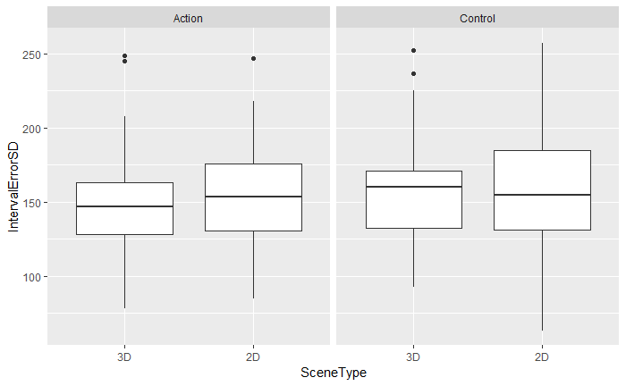

No apparent difference in precision.

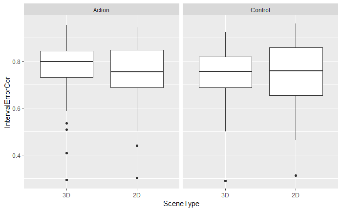

Correlation between reality and estimate seems slightly worse for 2D in Action condition..

### Intervals RT exploration

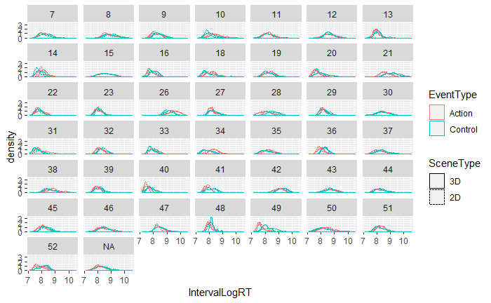

Log RTs seem sufficiently normally distributed with similar variances

Are ther outlier trials in the RTs?

RTs are around 2-10 seconds, there is a pretty long tail, but log-transformed seems ok-ish, seems no need to remove outliers.. But not much of a difference among conditions..

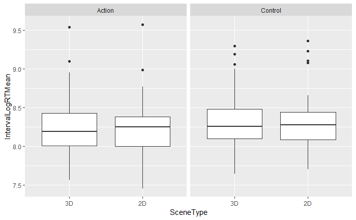

Interval RTs seem to be very similar acrosss conditions

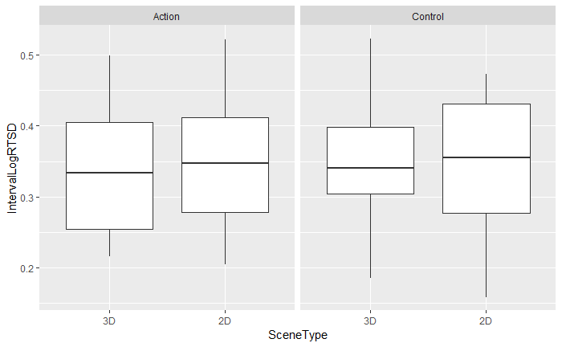

No interesting difference..

### Interval RT mixed-effects model

IntervalLogRT ~ ObjectsCount + Interval + SceneType * EventType + (1+SceneType + EventType|Subject)

|  | Interval Log RT |  |  |
| --- | --- | --- | --- |
| Predictors | Estimates | CI | p |
| (Intercept) | 8.33598 | 8.21394 – 8.45801 | **<0.001** |
| Objects Count | -0.00250 | -0.00615 – 0.00115 | 0.180 |
| Interval | -0.00015 | -0.00018 – -0.00011 | **<0.001** |
| SceneType2D | -0.00143 | -0.03419 – 0.03133 | 0.932 |
| EventTypeControl | 0.06199 | -0.01309 – 0.13706 | 0.112 |
| SceneType2D:EventTypeControl | -0.02013 | -0.05350 – 0.01324 | 0.237 |
| Random Effects |  |  |  |
| σ<sup>2</sup> | 0.12 |  |  |
| τ<sub>00</sub> <sub>Subject</sub> | 0.15 |  |  |
| τ<sub>11</sub> <sub>Subject.SceneType2D</sub> | 0.01 |  |  |
| τ<sub>11</sub> <sub>Subject.EventTypeControl</sub> | 0.06 |  |  |
| ρ<sub>01</sub> <sub>Subject.SceneType2D</sub> | -0.22 |  |  |
| ρ<sub>01</sub> <sub>Subject.EventTypeControl</sub> | -0.40 |  |  |
| ICC <sub>Subject</sub> | 0.55 |  |  |
| Observations | 6880 |  |  |
| Marginal R<sup>2</sup> / Conditional R<sup>2</sup> | 0.007 / 0.534 |  |  |

Nothing very interesting

## Explore removing first half of each block

WP: “Sometimes participants need a number of initial trials to adapt to the processing conditions of a given experimental block (particularly if this block was preceded by another one with quite different processing requirements). If this happens, it may be useful to take still another look at the data, disregarding, say, the first half of trials of each block and just concentrating on the trials in the second half.”

```
Caution! ICC for random-slope-intercept models usually not meaningful. See 'Note' in `?icc`.
```

|  | Interval Error |  |  |
| --- | --- | --- | --- |
| Predictors | Estimates | CI | p |
| (Intercept) | -42.04 | -65.50 – -18.59 | **0.001** |
| Interval S | -68.22 | -80.22 – -56.23 | **<0.001** |
| SceneType2D | 1.64 | -12.81 – 16.08 | 0.825 |
| EventTypeControl | 97.50 | 74.10 – 120.89 | **<0.001** |
| SceneType2D:EventTypeControl | 2.88 | -15.27 – 21.02 | 0.756 |
| Random Effects |  |  |  |
| σ<sup>2</sup> | 18391.04 |  |  |
| τ<sub>00</sub> <sub>Subject</sub> | 5225.00 |  |  |
| τ<sub>11</sub> <sub>Subject.IntervalS</sub> | 1366.83 |  |  |
| τ<sub>11</sub> <sub>Subject.SceneType2D</sub> | 493.97 |  |  |
| τ<sub>11</sub> <sub>Subject.EventTypeControl</sub> | 4270.22 |  |  |
| ρ<sub>01</sub> <sub>Subject.IntervalS</sub> | 0.25 |  |  |
| ρ<sub>01</sub> <sub>Subject.SceneType2D</sub> | 0.05 |  |  |
| ρ<sub>01</sub> <sub>Subject.EventTypeControl</sub> | -0.59 |  |  |
| ICC <sub>Subject</sub> | 0.22 |  |  |
| Observations | 3440 |  |  |
| Marginal R<sup>2</sup> / Conditional R<sup>2</sup> | 0.223 / 0.417 |  |  |

Removing first half of each block still does not produce significant effect of 2Dvs3D nor interaction with EventType

## Explore sequence effects

WP: As I understand, there were always four blocks in a session, resulting from 2x2 scene types and event types. Now, if the sequence of these blocks is balanced over participants, some of them will have sequences like 2-2-3-3 and 3-3-2-2, whereas others will have mixed sequences like 2-3-2-3 or -3-2-3-2 (where 2 and 3 stand for 2D/3D). I don’t have directed hypotheses, but it could be interesting to take a look at whether these sequence-defined subgroups show any differences in terms of agency strength.

OH: Regarding the sequence effects, the design looked like this: there were 8 blocks, each block had 20 trials. There were 2 between-subjects factors: FirstSceneType (first block was 2D or 3D, then the type changed after each block) and FirstEventType (first four blocks were Action and last four blocks were Control (Vibration) or vice versa). Therefore there were 2x2 groups of participants.

Let’s try to have a look at (an almost) full model: `IntervalError ~ Interval + SceneType * EventType * FirstSceneType * FirstEventType + (1+Interval + SceneType * EventType|Subject)`

```
Caution! ICC for random-slope-intercept models usually not meaningful. See 'Note' in `?icc`.
```

|  | Interval Error |  |  |
| --- | --- | --- | --- |
| Predictors | Estimates | CI | p |
| (Intercept) | -14.28 | -54.48 – 25.93 | 0.490 |
| Interval S | -70.42 | -81.92 – -58.92 | **<0.001** |
| SceneType2D | 13.23 | -13.24 – 39.70 | 0.333 |
| EventTypeControl | 103.15 | 63.77 – 142.53 | **<0.001** |
| FirstSceneType2D | 5.01 | -49.56 – 59.58 | 0.858 |
| FirstEventTypeControl | -64.34 | -120.09 – -8.60 | **0.029** |
| SceneType2D:EventTypeControl | -32.22 | -67.37 – 2.93 | 0.080 |
| SceneType2D:FirstSceneType2D | -37.03 | -73.65 – -0.42 | 0.055 |
| EventTypeControl:FirstSceneType2D | -55.20 | -109.30 – -1.10 | 0.053 |
| SceneType2D:FirstEventTypeControl | -4.25 | -41.65 – 33.15 | 0.825 |
| EventTypeControl:FirstEventTypeControl | 25.33 | -29.94 – 80.59 | 0.375 |
| FirstSceneType2D:FirstEventTypeControl | -13.03 | -93.22 – 67.16 | 0.752 |
| SceneType2D:EventTypeControl:FirstSceneType2D | 63.49 | 14.84 – 112.15 | **0.015** |
| SceneType2D:EventTypeControl:FirstEventTypeControl | 15.96 | -33.74 – 65.66 | 0.533 |
| SceneType2D:FirstSceneType2D:FirstEventTypeControl | 13.92 | -39.89 – 67.72 | 0.615 |
| EventTypeControl:FirstSceneType2D:FirstEventTypeControl | 41.88 | -37.62 – 121.39 | 0.308 |
| SceneType2D:EventTypeControl:FirstSceneType2D:FirstEventTypeControl | -15.49 | -86.99 – 56.00 | 0.673 |
| Random Effects |  |  |  |
| σ<sup>2</sup> | 18621.50 |  |  |
| τ<sub>00</sub> <sub>Subject</sub> | 4682.07 |  |  |
| τ<sub>11</sub> <sub>Subject.IntervalS</sub> | 1364.24 |  |  |
| τ<sub>11</sub> <sub>Subject.SceneType2D</sub> | 1084.33 |  |  |
| τ<sub>11</sub> <sub>Subject.EventTypeControl</sub> | 3705.24 |  |  |
| τ<sub>11</sub> <sub>Subject.SceneType2D:EventTypeControl</sub> | 1683.15 |  |  |
| ρ<sub>01</sub> <sub>Subject.IntervalS</sub> | 0.40 |  |  |
| ρ<sub>01</sub> <sub>Subject.SceneType2D</sub> | -0.33 |  |  |
| ρ<sub>01</sub> <sub>Subject.EventTypeControl</sub> | -0.57 |  |  |
| ρ<sub>01</sub> <sub>Subject.SceneType2D:EventTypeControl</sub> | 0.33 |  |  |
| ICC <sub>Subject</sub> | 0.20 |  |  |
| Observations | 6880 |  |  |
| Marginal R<sup>2</sup> / Conditional R<sup>2</sup> | 0.253 / 0.423 |  |  |

Model is too complex to work with (at least we see there is no interaction of FirstSceneType:FirstEventType), so let’s split it by investigating the two between-subjects factors separately.

### Effects of FirstSceneType: starting with 2D or 3D block

```
Caution! ICC for random-slope-intercept models usually not meaningful. See 'Note' in `?icc`.
```

|  | Interval Error |  |  |
| --- | --- | --- | --- |
| Predictors | Estimates | CI | p |
| (Intercept) | -45.74 | -77.49 – -13.98 | **0.007** |
| Interval S | -70.42 | -81.92 – -58.92 | **<0.001** |
| SceneType2D | 11.03 | -7.31 – 29.37 | 0.245 |
| EventTypeControl | 115.24 | 86.04 – 144.45 | **<0.001** |
| FirstSceneType2D | 2.56 | -41.87 – 46.99 | 0.911 |
| SceneType2D:EventTypeControl | -24.27 | -48.64 – 0.11 | 0.058 |
| SceneType2D:FirstSceneType2D | -30.62 | -56.82 – -4.43 | **0.027** |
| EventTypeControl:FirstSceneType2D | -37.88 | -79.32 – 3.55 | 0.080 |
| SceneType2D:EventTypeControl:FirstSceneType2D | 55.77 | 20.91 – 90.62 | **0.003** |
| Random Effects |  |  |  |
| σ<sup>2</sup> | 18621.50 |  |  |
| τ<sub>00</sub> <sub>Subject</sub> | 5550.52 |  |  |
| τ<sub>11</sub> <sub>Subject.IntervalS</sub> | 1364.24 |  |  |
| τ<sub>11</sub> <sub>Subject.SceneType2D</sub> | 1003.70 |  |  |
| τ<sub>11</sub> <sub>Subject.EventTypeControl</sub> | 4035.36 |  |  |
| τ<sub>11</sub> <sub>Subject.SceneType2D:EventTypeControl</sub> | 1543.88 |  |  |
| ρ<sub>01</sub> <sub>Subject.IntervalS</sub> | 0.31 |  |  |
| ρ<sub>01</sub> <sub>Subject.SceneType2D</sub> | -0.31 |  |  |
| ρ<sub>01</sub> <sub>Subject.EventTypeControl</sub> | -0.63 |  |  |
| ρ<sub>01</sub> <sub>Subject.SceneType2D:EventTypeControl</sub> | 0.25 |  |  |
| ICC <sub>Subject</sub> | 0.23 |  |  |
| Observations | 6880 |  |  |
| Marginal R<sup>2</sup> / Conditional R<sup>2</sup> | 0.235 / 0.418 |  |  |

Interaction SceneType:FirstSceneType seems trivial: practice effect. The 3-way interaction may be interesting. Split the 3-way interaction to two 2-way interactions, one for each FirstSceneType. First when people started with 2D block:

```
Caution! ICC for random-slope-intercept models usually not meaningful. See 'Note' in `?icc`.
```

|  | Interval Error |  |  |
| --- | --- | --- | --- |
| Predictors | Estimates | CI | p |
| (Intercept) | -47.14 | -85.92 – -8.36 | **0.027** |
| Interval S | -77.29 | -92.79 – -61.78 | **<0.001** |
| SceneType2D | -20.30 | -39.42 – -1.17 | 0.051 |
| EventTypeControl | 79.65 | 47.07 – 112.23 | **<0.001** |
| SceneType2D:EventTypeControl | 32.00 | 0.92 – 63.08 | 0.057 |
| Random Effects |  |  |  |
| σ<sup>2</sup> | 19610.32 |  |  |
| τ<sub>00</sub> <sub>Subject</sub> | 7730.76 |  |  |
| τ<sub>11</sub> <sub>Subject.IntervalS</sub> | 1191.32 |  |  |
| τ<sub>11</sub> <sub>Subject.SceneType2D</sub> | 1019.40 |  |  |
| τ<sub>11</sub> <sub>Subject.EventTypeControl</sub> | 4822.98 |  |  |
| τ<sub>11</sub> <sub>Subject.SceneType2D:EventTypeControl</sub> | 3319.22 |  |  |
| ρ<sub>01</sub> <sub>Subject.IntervalS</sub> | 0.19 |  |  |
| ρ<sub>01</sub> <sub>Subject.SceneType2D</sub> | -0.57 |  |  |
| ρ<sub>01</sub> <sub>Subject.EventTypeControl</sub> | -0.66 |  |  |
| ρ<sub>01</sub> <sub>Subject.SceneType2D:EventTypeControl</sub> | 0.49 |  |  |
| ICC <sub>Subject</sub> | 0.28 |  |  |
| Observations | 3360 |  |  |
| Marginal R<sup>2</sup> / Conditional R<sup>2</sup> | 0.238 / 0.439 |  |  |

For those who started with 2D block, there is a marginal main effect of SceneType (Intervals were underestimated more by 20 ms), which may be just the practice effect (with a lot of practice there may be no under- or over-estimation), but interestingly there is marginal interaction between SceneType and EventType. See chart below.

```
Caution! ICC for random-slope-intercept models usually not meaningful. See 'Note' in `?icc`.
```

|  | Interval Error |  |  |
| --- | --- | --- | --- |
| Predictors | Estimates | CI | p |
| (Intercept) | -41.95 | -68.18 – -15.72 | **0.005** |
| Interval S | -63.87 | -80.68 – -47.06 | **<0.001** |
| SceneType2D | 11.70 | -6.87 – 30.27 | 0.230 |
| EventTypeControl | 113.05 | 85.60 – 140.50 | **<0.001** |
| SceneType2D:EventTypeControl | -24.75 | -44.36 – -5.13 | **0.017** |
| Random Effects |  |  |  |
| σ<sup>2</sup> | 17640.53 |  |  |
| τ<sub>00</sub> <sub>Subject</sub> | 3498.80 |  |  |
| τ<sub>11</sub> <sub>Subject.IntervalS</sub> | 1507.68 |  |  |
| τ<sub>11</sub> <sub>Subject.SceneType2D</sub> | 1092.76 |  |  |
| τ<sub>11</sub> <sub>Subject.EventTypeControl</sub> | 3433.27 |  |  |
| τ<sub>11</sub> <sub>Subject.SceneType2D:EventTypeControl</sub> | 439.61 |  |  |
| ρ<sub>01</sub> <sub>Subject.IntervalS</sub> | 0.48 |  |  |
| ρ<sub>01</sub> <sub>Subject.SceneType2D</sub> | 0.02 |  |  |
| ρ<sub>01</sub> <sub>Subject.EventTypeControl</sub> | -0.59 |  |  |
| ρ<sub>01</sub> <sub>Subject.SceneType2D:EventTypeControl</sub> | -0.65 |  |  |
| ICC <sub>Subject</sub> | 0.17 |  |  |
| Observations | 3520 |  |  |
| Marginal R<sup>2</sup> / Conditional R<sup>2</sup> | 0.229 / 0.393 |  |  |

Starting with a 3D block, now there is a trully significant interaction of SceneType and EventType. What does this mean? Let’s graph it..

```
Ignoring unknown aesthetics: y
```

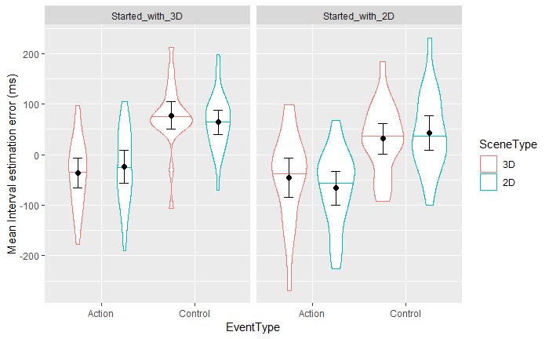

In Started_with_3D (left panel) there is an interaction of SceneType and EventType. Interval estimation errors are “more extreme” for 3D scenes. In Started_with_2D it is a bit (nonsig) reversed: more extreme errors for 2D. This could be learning effect, learning to estimate closer to reality (error of zero) after some practice. This is still hard to interpret, so let’s take a difference score of Control - Action (“agency effect”, higher values = stronger effect).

```
Converting "Subject" to factor for ANOVA.Converting "SceneType" to factor for ANOVA.Converting "FirstSceneTypeGraph" to factor for ANOVA.The column supplied as the wid variable contains non-unique values across levels of the supplied between-Ss variables. Automatically fixing this by generating uniq…
```

|  | Effect | DFn | DFd | F | p | p<.05 | ges |
| --- | --- | --- | --- | --- | --- | --- | --- |
| 2 | FirstSceneTypeGraph | 1 | 43 | 0.1582346 | 0.692755076 |  | 0.0030648086 |
| 3 | SceneType | 1 | 43 | 0.1399187 | 0.710200000 |  | 0.0005352539 |
| 4 | FirstSceneTypeGraph:SceneType | 1 | 43 | 11.1168461 | 0.001768471 | * | 0.0408132560 |

```
NA
```

Agency size sig. depends on interaction of SceneType (2D vs 3D) and FirstSceneType (first block being 2D vs 3D).

```
Ignoring unknown aesthetics: y
```

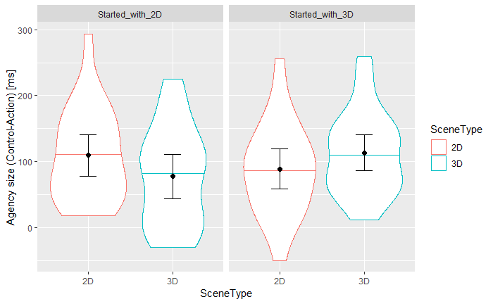

Does this mean anything? People learn to estimate better? That would be my (and probably reviewers’) first explanation, which we cannot exclude using our data, which is why our primary analysis uses all data from a balanced design (and finds nothing :-( )..

### Effects of FirstEventType: starting with an Action or Control (Vibration) block

```
Caution! ICC for random-slope-intercept models usually not meaningful. See 'Note' in `?icc`.
```

|  | Interval Error |  |  |
| --- | --- | --- | --- |
| Predictors | Estimates | CI | p |
| (Intercept) | -11.68 | -39.44 – 16.07 | 0.414 |
| Interval S | -70.42 | -81.92 – -58.92 | **<0.001** |
| SceneType2D | -5.78 | -24.84 – 13.29 | 0.556 |
| EventTypeControl | 74.78 | 46.84 – 102.72 | **<0.001** |
| FirstEventTypeControl | -70.53 | -109.56 – -31.49 | **0.001** |
| SceneType2D:EventTypeControl | 0.34 | -26.19 – 26.87 | 0.980 |
| SceneType2D:FirstEventTypeControl | 3.98 | -23.83 – 31.79 | 0.780 |
| EventTypeControl:FirstEventTypeControl | 47.21 | 6.60 – 87.82 | **0.028** |
| SceneType2D:EventTypeControl:FirstEventTypeControl | 5.65 | -33.09 – 44.39 | 0.776 |
| Random Effects |  |  |  |
| σ<sup>2</sup> | 18621.50 |  |  |
| τ<sub>00</sub> <sub>Subject</sub> | 4467.38 |  |  |
| τ<sub>11</sub> <sub>Subject.IntervalS</sub> | 1364.24 |  |  |
| τ<sub>11</sub> <sub>Subject.SceneType2D</sub> | 1263.58 |  |  |
| τ<sub>11</sub> <sub>Subject.EventTypeControl</sub> | 3812.85 |  |  |
| τ<sub>11</sub> <sub>Subject.SceneType2D:EventTypeControl</sub> | 2383.47 |  |  |
| ρ<sub>01</sub> <sub>Subject.IntervalS</sub> | 0.41 |  |  |
| ρ<sub>01</sub> <sub>Subject.SceneType2D</sub> | -0.25 |  |  |
| ρ<sub>01</sub> <sub>Subject.EventTypeControl</sub> | -0.53 |  |  |
| ρ<sub>01</sub> <sub>Subject.SceneType2D:EventTypeControl</sub> | 0.22 |  |  |
| ICC <sub>Subject</sub> | 0.19 |  |  |
| Observations | 6880 |  |  |
| Marginal R<sup>2</sup> / Conditional R<sup>2</sup> | 0.249 / 0.421 |  |  |

Only trivial effects. No 3-way interaction, so no need to make the detailed split analyses as for FirstSceneType above.. (I tried anyway and there was still no interesting effect related to agency, no effect of SceneType nor interaction with EventType). At least a chart:

```
Ignoring unknown aesthetics: y
```

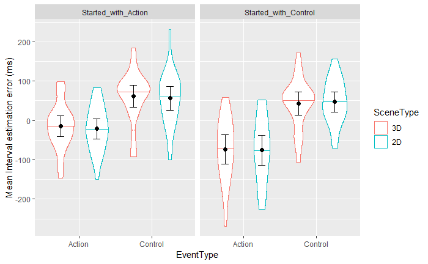

Those who started with Control blocks (right panel; first half of experiment was Control) underestimated the intervals more in Action blocks (second half of experiment), than did people who started with Action blocks (left panel). This could be trivial, or there could be some story like: People get used to having no control over production of the tone in the first half of experiment and then, in the second half, when they get to cause the tones by their actions, they underestimate a lot = have strong sense of agency. In comparison, people who start with Action are fairly accurate, do not underestimate much, and later when they lose control in the Control blocks, they for some reason do not feel less in control than people who started with control block. Does it make sense? What would it mean? What followup could confirm it?

In any case, there is no influence of Scene type.

Let’s have a look also at the difference scores of Control-Action.

```
Converting "Subject" to factor for ANOVA.Converting "SceneType" to factor for ANOVA.Converting "FirstEventTypeGraph" to factor for ANOVA.Data is unbalanced (unequal N per group). Make sure you specified a well-considered value for the type argument to ezANOVA().
```

|  | Effect | DFn | DFd | F | p | p<.05 | ges |
| --- | --- | --- | --- | --- | --- | --- | --- |
| 2 | FirstEventTypeGraph | 1 | 42 | 5.56474218 | 0.02305258 | * | 0.0937827754 |
| 3 | SceneType | 1 | 42 | 0.11435581 | 0.73692319 |  | 0.0005957134 |
| 4 | FirstEventTypeGraph:SceneType | 1 | 42 | 0.04886317 | 0.82612454 |  | 0.0002546297 |

```
NA
```

```
Ignoring unknown aesthetics: y
```

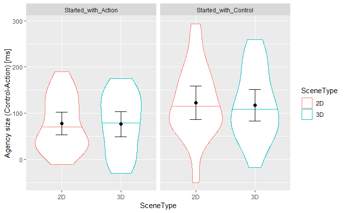

There is a sig. difference between left and right panel. But it is really hard to say whether this is trivial, due to practice, it is an order effect.. Any ideas?

# Metacognition

Did errors people made correspond to their overall confidence ratings?

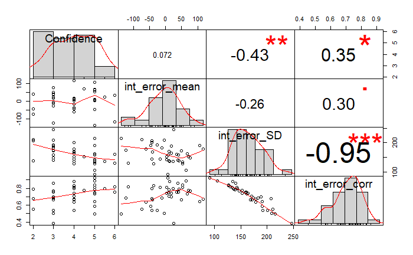

- High confidence correlates with lower variation in interval estimation errors = with higher **precision of estimation**.
- High confidence correlates with high correlation between actual and estimated intervals = with higher **ability to discriminate time intervals**.
- Interestingly, correlation(Actual, Estimated) is very strongly correlated with SD(Actual-Estimated), but this may be mathematical “effect”?

Therefore, people have overall some insight into their ability to discriminate short (sub-second) time intervals.